# SVM_FaceDetection

```python
from sklearn.datasets import fetch_lfw_people
faces = fetch_lfw_people(min_faces_per_person=60)
print(faces.target_names)
print(faces.images.shape)
```

[output not shown]

با استفاده از یک دیتاست معروف و آموزشی که حاوی چهره های افراد مشهور دنیای سیاست میباشد این سیستم طراحی شده است

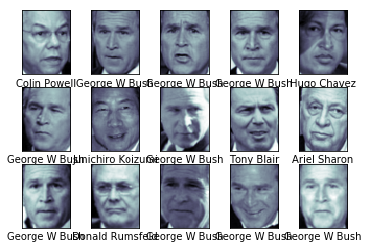

```python
import matplotlib.pyplot as plt
fig, ax = plt.subplots(3, 5)
for i, axi in enumerate(ax.flat):
    axi.imshow(faces.images[i], cmap='bone')
    axi.set(xticks=[], yticks=[],
            xlabel=faces.target_names[faces.target[i]])
```

تصاویری و نام هایی که مشاهده میکنید ،از دیتاست بیرون کشیده شده اند و مدل ما سعی خواهد کرد که فرآیند آموزش خود را به کمک این نام ها و تصاویر انجام دهد

```python
from sklearn.svm import SVC
from sklearn.decomposition import RandomizedPCA
from sklearn.pipeline import make_pipeline

pca = RandomizedPCA(n_components=150, whiten=True, random_state=42)
svc = SVC(kernel='rbf', class_weight='balanced')
model = make_pipeline(pca, svc)
```

```python
from sklearn.cross_validation import train_test_split
Xtrain, Xtest, ytrain, ytest = train_test_split(faces.data, faces.target,
                                                random_state=42)
```

```python
from sklearn.grid_search import GridSearchCV
param_grid = {'svc__C': [1, 5, 10, 50],
              'svc__gamma': [0.0001, 0.0005, 0.001, 0.005]}
grid = GridSearchCV(model, param_grid)

%time grid.fit(Xtrain, ytrain)
print(grid.best_params_)
```

[output not shown]

```python
model = grid.best_estimator_
yfit = model.predict(Xtest)
```

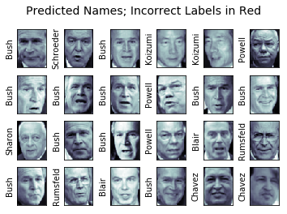

```python
fig, ax = plt.subplots(4, 6)
for i, axi in enumerate(ax.flat):
    axi.imshow(Xtest[i].reshape(62, 47), cmap='bone')
    axi.set(xticks=[], yticks=[])
    axi.set_ylabel(faces.target_names[yfit[i]].split()[-1],
                   color='black' if yfit[i] == ytest[i] else 'red')
fig.suptitle('Predicted Names; Incorrect Labels in Red', size=14);
```

```python
from sklearn.metrics import classification_report
print(classification_report(ytest, yfit,
                            target_names=faces.target_names))
```

```
                   precision    recall  f1-score   support

     Ariel Sharon       0.62      0.87      0.72        15
     Colin Powell       0.82      0.88      0.85        68
  Donald Rumsfeld       0.74      0.84      0.79        31
    George W Bush       0.98      0.82      0.89       126
Gerhard Schroeder       0.76      0.83      0.79        23
      Hugo Chavez       0.88      0.70      0.78        20
Junichiro Koizumi       0.80      1.00      0.89        12
       Tony Blair       0.85      0.95      0.90        42

      avg / total       0.87      0.85      0.85       337
```

گزارشی که مشاهده میکنید ، اطلاعات و گزارش مربوط به پیشبینی تشخیص برای نام و تصویر هر یک از افراد است

# confusion_matrix and seaborn

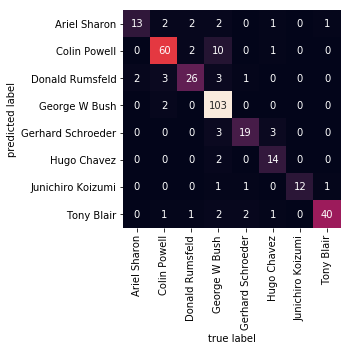

```python
import seaborn as sns
from sklearn.metrics import confusion_matrix
mat = confusion_matrix(ytest, yfit)
sns.heatmap(mat.T, square=True, annot=True, fmt='d', cbar=False,
            xticklabels=faces.target_names,
            yticklabels=faces.target_names)
plt.xlabel('true label')
plt.ylabel('predicted label');
```

در این ماتریس میتوانید جزییات تشخیص و پیشبینی سیستم طراحی شده و تست شده بر روی داده ها ی تست را مشاهده کنید ، برای مثال : جورج بوش 103 بار به درستی تشخیص داده شده است ، و مثلا 10 بار با آقای کالین پاول اشتباه گرفته شده است.

آقای شارون 13 بار به درستی و تنها دو بار با آقای رامسفلد اشتباه گرفته شده است

گفتنیست که این سیستم جنبه آموزشی و تست داشته است

علی عسگری - امیرحسین شهدادیان